# Caldana

Liland

2023-11-05

# Example wishlist

- HDANOVA: ASCA, APCA, ASCA+,
- Vegan: PRC,
- MEDA toolbox: VASCA, GASCA (no joy)

## Comments:

- There are no replicates, so no interactions are used in the models.
- Timepoint 0 is removed to achieve fully crossed design.
- ASCA and ASCA+ should give equal results since the design is balanced?!
- Should we scale the data? Scaling has not been applied yet on ASCA or PRC. VASCA and GASCA apparently autoscale by default.
- For VASCA and GASCA I tried to follow the MEDA toolbox examples and correct them where they were impossible to run (possibly updated functions and old examples?).
- As I read the output of VASCA, when tested on the metabolomics data (including both condition and time), all variables are maximally significant (minimum P-value).
- GASCA on metabolomics data ran for several hours without converging. For the expression data, almost 40 GB of memory was consumed before getting to the main GASCA routine, thus crashing.

```r
load("caldana_selected.RData")
```

# Remove timepoint 0 to achieve full crossed design

```r
# Remove timepoint 0
metabolomics <- metabolomics[metabolomics$time!="0",]
metabolomics$time <- factor(metabolomics$time)
expressions <- expressions[expressions$time!="0",]
expressions$time <- factor(expressions$time)
```

# ASCA(+)

metabolomics ~ condition + time

## Metabolomics

(ASCA)

```r
#res <- HDANOVA:::.asca(metabolomics~condition+time, metabolomics)
#scoreplot(res, legendpos = "top")
res2 <- multiblock::asca(metabolomics~condition+time, metabolomics)
expl <- attr(res2$scores$condition, "explvar")

summary(res2)
```

```
## Anova Simultaneous Component Analysis fitted using 'lm' (Linear Model)
##                ss expl
## condition 1611.90 0.55
## time       405.65 0.14
```

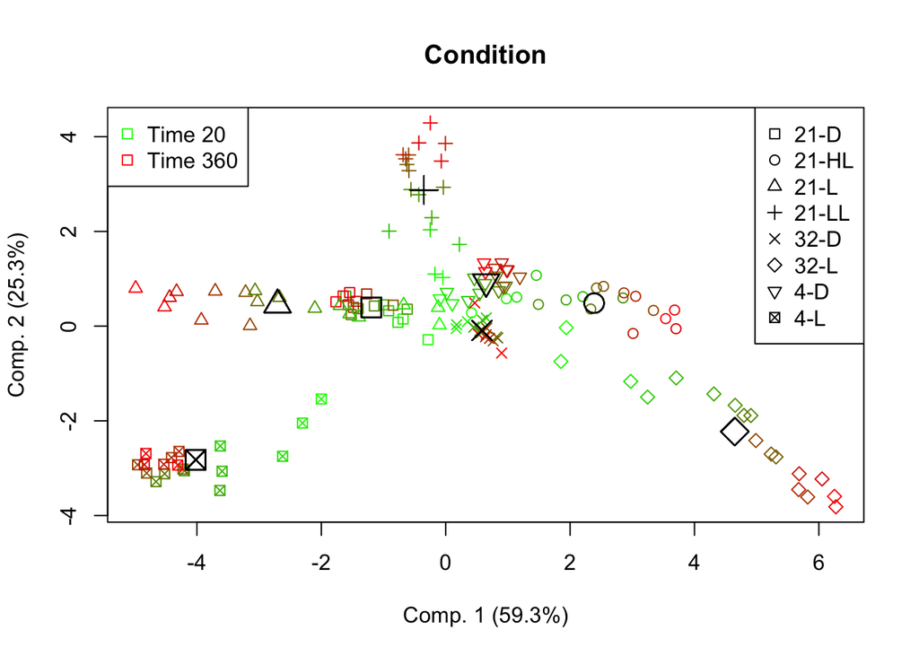

```r
# Scoreplot
plot(res2$projected$condition[,1]+res2$scores$condition[,1],
     res2$projected$condition[,2]+res2$scores$condition[,2],
     col=rgb(seq(0,1, length.out=18),seq(1,0, length.out=18),0),
     pch=rep(0:7,each=18),
     xlab = paste0("Comp. 1 (", round(expl[1],1), "%)"),
     ylab = paste0("Comp. 2 (", round(expl[2],1), "%)"),
     main = "Condition"
)
points(res2$scores$condition[,1], res2$scores$condition[,2], pch=rep(0:7,each=18), cex=2)
legend("topright", legend=levels(metabolomics$condition), pch=0:7)
legend("topleft", legend=c("Time 20", "Time 360"), pch=c(0,0), col=rgb(c(0,1),c(1,0),c(0,0)))
```

## Expressions

(ASCA)

```r
#res <- HDANOVA:::.asca(metabolomics~condition+time, metabolomics)
#scoreplot(res, legendpos = "top")
res2 <- multiblock::asca(expression~condition+time, expressions)
expl <- attr(res2$scores$condition, "explvar")

summary(res2)
```

```
## Anova Simultaneous Component Analysis fitted using 'lm' (Linear Model)
##                 ss expl
## condition 427548.5 0.54
## time      158292.9 0.20
```

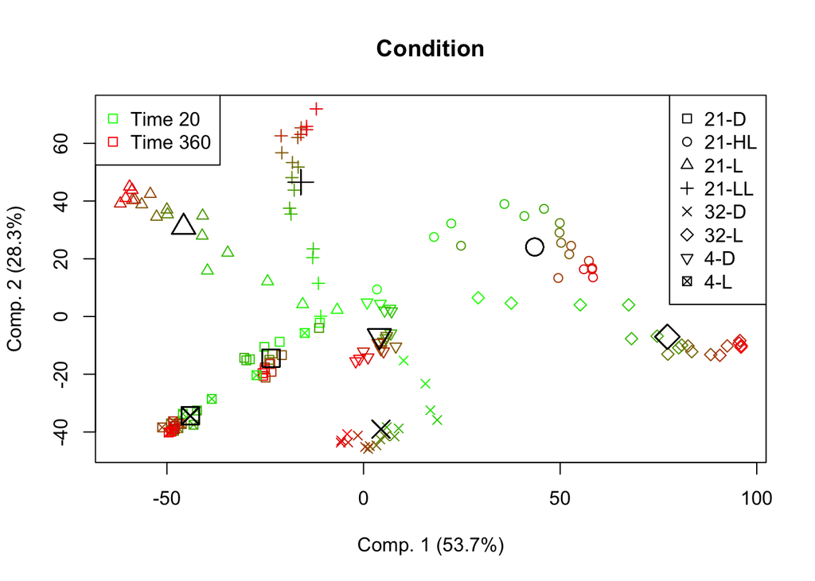

```r
# Scoreplot
plot(res2$projected$condition[,1]+res2$scores$condition[,1],
     res2$projected$condition[,2]+res2$scores$condition[,2],
     col=rgb(seq(0,1, length.out=18),seq(1,0, length.out=18),0),
     pch=rep(0:7,each=18),
     xlab = paste0("Comp. 1 (", round(expl[1],1), "%)"),
     ylab = paste0("Comp. 2 (", round(expl[2],1), "%)"),
     main = "Condition"
)
points(res2$scores$condition[,1], res2$scores$condition[,2], pch=rep(0:7,each=18), cex=2)
legend("topright", legend=levels(expressions$condition), pch=0:7)
legend("topleft", legend=c("Time 20", "Time 360"), pch=c(0,0), col=rgb(c(0,1),c(1,0),c(0,0)))
```

# PRC

## Metabolomics

(PRC)

```r
res_metabolomics <- prc(metabolomics$metabolomics, metabolomics$condition, metabolomics$time)
```

### RDA

```r
res_metabolomics
```

```
## Call: prc(response = metabolomics$metabolomics, treatment =
## metabolomics$condition, time = metabolomics$time)
##
##               Inertia Proportion Rank
## Total         20.3797     1.0000
## Conditional    2.8367     0.1392   17
## Constrained   17.5430     0.8608   92
## Unconstrained  0.0000     0.0000    0
## Inertia is variance
##
## Eigenvalues for constrained axes:
##  RDA1  RDA2  RDA3  RDA4  RDA5  RDA6  RDA7  RDA8  RDA9 RDA10 RDA11 RDA12 RDA13
## 7.486 3.196 1.695 1.159 0.607 0.440 0.425 0.322 0.230 0.171 0.143 0.131 0.116
## RDA14 RDA15 RDA16 RDA17 RDA18 RDA19 RDA20 RDA21 RDA22 RDA23 RDA24 RDA25 RDA26
## 0.109 0.096 0.090 0.086 0.072 0.068 0.065 0.057 0.056 0.052 0.048 0.045 0.039
## RDA27 RDA28 RDA29 RDA30 RDA31 RDA32 RDA33 RDA34 RDA35 RDA36 RDA37 RDA38 RDA39
## 0.039 0.037 0.034 0.030 0.027 0.026 0.025 0.022 0.020 0.019 0.018 0.018 0.015
## RDA40 RDA41 RDA42 RDA43 RDA44 RDA45 RDA46 RDA47 RDA48 RDA49 RDA50 RDA51 RDA52
## 0.014 0.014 0.013 0.011 0.010 0.010 0.010 0.009 0.008 0.008 0.007 0.007 0.006
## RDA53 RDA54 RDA55 RDA56 RDA57 RDA58 RDA59 RDA60 RDA61 RDA62 RDA63 RDA64 RDA65
## 0.006 0.006 0.006 0.005 0.005 0.005 0.004 0.004 0.004 0.003 0.003 0.003 0.003
## RDA66 RDA67 RDA68 RDA69 RDA70 RDA71 RDA72 RDA73 RDA74 RDA75 RDA76 RDA77 RDA78
## 0.003 0.002 0.002 0.002 0.002 0.002 0.002 0.001 0.001 0.001 0.001 0.001 0.001
## RDA79 RDA80 RDA81 RDA82 RDA83 RDA84 RDA85 RDA86 RDA87 RDA88 RDA89 RDA90 RDA91
## 0.001 0.001 0.001 0.001 0.001 0.001 0.000 0.000 0.000 0.000 0.000 0.000 0.000
## RDA92
## 0.000
```

### PRC

```r
summary(res_metabolomics)
```

```
##
## Call:
## prc(response = metabolomics$metabolomics, treatment = metabolomics$condition,      time = metabolomics$time)
## Species scores:
##                              4-hydroxy-benzoic acid
##                                          -0.0797760
##                              4-Hydroxycinnamic acid
##                                          -0.0290908
##                                             Alanine
##                                           0.0592208
##                                           Arabinose
##                                          -0.3824784
##                                            Arabitol
##                                          -0.0774900
##                                       Ascorbic acid
##                                           0.0379534
##                                          Asparagine
##                                          -0.7990133
##                                           Aspartate
##                                          -0.1126958
##                                        Benzoic acid
##                                           0.0238055
##                                        beta-alanine
##                                          -0.6886898
##                                         Citramalate
##                                           0.0899142
##                                         Citric acid
##                                           0.0890823
##                                 Citrulline/Arginine
##                                           0.0637561
##                                Dehydroascorbic acid
##                                          -0.0948129
##                          Dehydroascorbic acid dimer
##                                           0.0096824
##                                     Docosanoic acid
##                                          -0.1069368
##                                          Erythritol
##                                          -0.1071145
##                                        Ethanolamine
##                                          -0.1458389
```

[output cut: 161 more lines]

```
## 21-HL  0.15639  0.14919  0.16846  0.19658  0.16762  0.16863  0.17803  0.20272
## 21-L   0.08655  0.09244  0.07653  0.11896  0.10561  0.10267  0.10647  0.12814
## 21-LL  0.03200  0.03659  0.03784  0.05256  0.04401  0.05304  0.04904  0.06887
## 32-D  -0.06114 -0.07173 -0.06818 -0.03963 -0.07355 -0.06560 -0.06740 -0.05630
## 32-L   0.04152  0.03502  0.03788  0.06651  0.05339  0.05565  0.05542  0.08217
## 4-D    0.05619  0.07394  0.08013  0.09991  0.08907  0.09100  0.07635  0.10453
## 4-L    0.11749  0.12948  0.13614  0.15595  0.15825  0.16491  0.17872  0.19702
##            340      360
## 21-HL  0.20093  0.18588
## 21-L   0.12761  0.13134
## 21-LL  0.07398  0.07445
## 32-D  -0.06548 -0.06679
## 32-L   0.07636  0.06423
## 4-D    0.09534  0.09919
## 4-L    0.20023  0.20726
```

### Plot

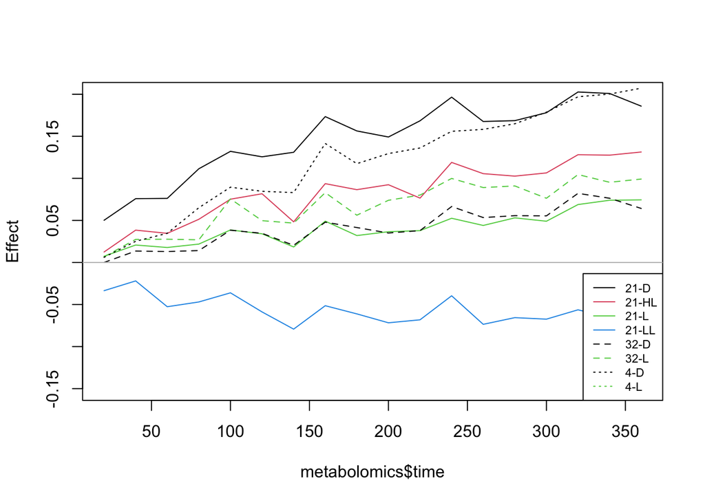

```r
plot(res_metabolomics, species = FALSE, lty=c(1,1,1,1,2,2,3,3), col=c(1,2,3,4,1,3,1,3), legpos = NA, ylim=c(-0.15,0.2))
legend("bottomright",legend = levels(expressions$condition),lty=c(1,1,1,1,2,2,3,3), col=c(1,2,3,4,1,3,1,3), cex=0.7)
```

## Expressions

(PRC)

```r
res_expressions <- prc(expressions$expression, expressions$condition, expressions$time)
summary(res_expressions)
```

```
##
## Call:
## prc(response = expressions$expression, treatment = expressions$condition,      time = expressions$time)
## Species scores:
##           AT2G26550           AT2G26570           AT2G26580           AT2G26360
##          -1.334e-01          -9.176e-03          -1.485e-01          -2.261e-02
##           AT2G26400           AT2G26560           AT2G26600           AT2G26530
##          -3.030e-01           5.592e-02           1.902e-02           2.576e-01
##           AT2G26540           AT2G26430           AT2G26500           AT2G26590
##           1.031e-03           4.294e-01          -1.575e-02           3.321e-02
##           AT2G26510           AT2G23320           AT2G26440           AT2G26460
##           7.215e-02           5.227e-01          -2.879e-01          -2.994e-02
##           AT2G26470           AT2G26480           AT2G39720           AT2G39770
##           5.707e-02          -1.501e-03          -6.168e-03          -2.409e-02
##           AT2G39730           AT2G39760           AT2G39795           AT2G39725
##          -2.532e-02           1.510e-02          -1.327e-01           1.227e-01
##           AT2G39750           AT2G39840           AT2G39780           AT2G23200
##          -3.209e-02          -5.740e-02           1.788e-02          -2.643e-02
##           AT2G23180           AT2G23170           AT2G23340           AT2G23330
##          -8.248e-02           3.405e-01          -3.220e-01           1.256e-01
##           AT2G23310           AT2G23290           AT2G23350           AT2G39830
##           2.169e-01           2.118e-01          -1.261e-01          -3.254e-02
##           AT2G39850           AT2G45290           AT2G40900           AT2G40950
##          -5.824e-02          -7.821e-02          -2.211e-01           1.234e-02
##           AT2G40815           AT2G40840           AT2G40860           AT2G40880
##           5.507e-02          -3.764e-01           1.172e-01           1.121e-02
##           AT2G40935           AT2G40940           AT2G40830           AT2G40930
##          -4.266e-03           1.475e-01           6.880e-02           2.757e-02
##           AT2G40890           AT2G41600           AT2G41650           AT2G41520
##          -3.158e-02           2.185e-02          -1.328e-01          -6.397e-02
##           AT2G41540           AT2G41630           AT2G41530           AT2G41620
##          -1.360e-01           7.899e-02           1.693e-02           5.014e-02
##           AT2G41560           AT2G41680           AT2G41640           AT2G39810
##           1.201e-01          -2.095e-01           2.068e-01           1.549e-04
##           AT2G47610           AT2G47420           AT2G47450           AT2G47580
##          -2.274e-02           1.922e-01           3.724e-02           3.232e-02
##           AT2G47460           AT2G47600           AT2G45340           AT2G45320
##          -1.455e-03           7.359e-02          -9.862e-03           9.593e-02
##           AT2G45310           AT2G45460           AT2G45190           AT2G45400
##          -1.189e-01           3.525e-02           3.798e-02           1.359e-01
```

[output cut: 7501 more lines]

```
## 21-HL -0.14280 -0.14121 -0.14595 -0.14527 -0.15291 -0.14282 -0.15676 -0.15821
## 21-L  -0.10741 -0.10761 -0.10835 -0.10799 -0.11423 -0.11085 -0.11979 -0.12214
## 21-LL -0.06398 -0.06453 -0.06482 -0.06418 -0.07050 -0.06821 -0.07720 -0.08657
## 32-D   0.04846  0.04314  0.05114  0.04624  0.05503  0.06506  0.05120  0.05679
## 32-L  -0.06459 -0.06332 -0.06791 -0.07449 -0.07397 -0.07199 -0.08675 -0.09180
## 4-D   -0.10441 -0.10207 -0.10574 -0.11354 -0.10816 -0.10335 -0.12231 -0.11674
## 4-L   -0.14966 -0.15029 -0.15549 -0.16514 -0.16263 -0.16469 -0.17698 -0.18342
##            320      340      360
## 21-HL -0.15446 -0.16082 -0.15929
## 21-L  -0.12167 -0.12516 -0.12404
## 21-LL -0.08137 -0.09001 -0.08780
## 32-D   0.06034  0.05688  0.05782
## 32-L  -0.09134 -0.09546 -0.09226
## 4-D   -0.11124 -0.11193 -0.11460
## 4-L   -0.17599 -0.18093 -0.18150
```

### RDA

```r
res_expressions
```

```
## Call: prc(response = expressions$expression, treatment =
## expressions$condition, time = expressions$time)
##
##                Inertia Proportion Rank
## Total         5506.192      1.000
## Conditional   1106.944      0.201   17
## Constrained   4399.249      0.799  126
## Unconstrained    0.000      0.000    0
## Inertia is variance
##
## Eigenvalues for constrained axes:
##   RDA1   RDA2   RDA3   RDA4   RDA5   RDA6   RDA7   RDA8   RDA9  RDA10  RDA11
## 1741.7  969.3  297.8  176.8  124.9  109.1   95.1   60.6   53.0   47.3   41.6
##  RDA12  RDA13  RDA14  RDA15  RDA16  RDA17  RDA18  RDA19  RDA20  RDA21  RDA22
##   32.4   30.5   29.7   25.7   22.0   19.8   17.4   16.8   15.0   13.6   12.9
##  RDA23  RDA24  RDA25  RDA26  RDA27  RDA28  RDA29  RDA30  RDA31  RDA32  RDA33
##   12.2   11.5   10.7   10.5    9.9    9.3    8.9    8.8    8.7    8.3    7.8
##  RDA34  RDA35  RDA36  RDA37  RDA38  RDA39  RDA40  RDA41  RDA42  RDA43  RDA44
##    7.2    7.0    6.8    6.5    6.4    6.2    5.9    5.9    5.6    5.5    5.5
##  RDA45  RDA46  RDA47  RDA48  RDA49  RDA50  RDA51  RDA52  RDA53  RDA54  RDA55
##    5.3    5.3    5.2    5.2    4.9    4.8    4.8    4.6    4.5    4.5    4.4
##  RDA56  RDA57  RDA58  RDA59  RDA60  RDA61  RDA62  RDA63  RDA64  RDA65  RDA66
##    4.4    4.3    4.2    4.2    4.1    4.1    4.1    4.0    4.0    4.0    3.9
##  RDA67  RDA68  RDA69  RDA70  RDA71  RDA72  RDA73  RDA74  RDA75  RDA76  RDA77
##    3.8    3.8    3.8    3.6    3.6    3.6    3.5    3.5    3.5    3.5    3.4
##  RDA78  RDA79  RDA80  RDA81  RDA82  RDA83  RDA84  RDA85  RDA86  RDA87  RDA88
##    3.4    3.4    3.3    3.3    3.3    3.2    3.2    3.2    3.1    3.1    3.1
##  RDA89  RDA90  RDA91  RDA92  RDA93  RDA94  RDA95  RDA96  RDA97  RDA98  RDA99
##    3.1    3.0    3.0    2.9    2.9    2.9    2.9    2.9    2.9    2.8    2.8
## RDA100 RDA101 RDA102 RDA103 RDA104 RDA105 RDA106 RDA107 RDA108 RDA109 RDA110
##    2.8    2.7    2.7    2.7    2.6    2.6    2.6    2.6    2.6    2.5    2.5
## RDA111 RDA112 RDA113 RDA114 RDA115 RDA116 RDA117 RDA118 RDA119 RDA120 RDA121
##    2.5    2.4    2.4    2.4    2.4    2.4    2.3    2.3    2.2    2.2    2.1
## RDA122 RDA123 RDA124 RDA125 RDA126
##    2.1    2.1    2.0    2.0    1.9
```

### PRC

```r
summary(res_expressions)
```

```
##
## Call:
## prc(response = expressions$expression, treatment = expressions$condition,      time = expressions$time)
## Species scores:
##           AT2G26550           AT2G26570           AT2G26580           AT2G26360
##          -1.334e-01          -9.176e-03          -1.485e-01          -2.261e-02
##           AT2G26400           AT2G26560           AT2G26600           AT2G26530
##          -3.030e-01           5.592e-02           1.902e-02           2.576e-01
##           AT2G26540           AT2G26430           AT2G26500           AT2G26590
##           1.031e-03           4.294e-01          -1.575e-02           3.321e-02
##           AT2G26510           AT2G23320           AT2G26440           AT2G26460
##           7.215e-02           5.227e-01          -2.879e-01          -2.994e-02
##           AT2G26470           AT2G26480           AT2G39720           AT2G39770
##           5.707e-02          -1.501e-03          -6.168e-03          -2.409e-02
##           AT2G39730           AT2G39760           AT2G39795           AT2G39725
##          -2.532e-02           1.510e-02          -1.327e-01           1.227e-01
##           AT2G39750           AT2G39840           AT2G39780           AT2G23200
##          -3.209e-02          -5.740e-02           1.788e-02          -2.643e-02
##           AT2G23180           AT2G23170           AT2G23340           AT2G23330
##          -8.248e-02           3.405e-01          -3.220e-01           1.256e-01
##           AT2G23310           AT2G23290           AT2G23350           AT2G39830
##           2.169e-01           2.118e-01          -1.261e-01          -3.254e-02
##           AT2G39850           AT2G45290           AT2G40900           AT2G40950
##          -5.824e-02          -7.821e-02          -2.211e-01           1.234e-02
##           AT2G40815           AT2G40840           AT2G40860           AT2G40880
##           5.507e-02          -3.764e-01           1.172e-01           1.121e-02
##           AT2G40935           AT2G40940           AT2G40830           AT2G40930
##          -4.266e-03           1.475e-01           6.880e-02           2.757e-02
##           AT2G40890           AT2G41600           AT2G41650           AT2G41520
##          -3.158e-02           2.185e-02          -1.328e-01          -6.397e-02
##           AT2G41540           AT2G41630           AT2G41530           AT2G41620
##          -1.360e-01           7.899e-02           1.693e-02           5.014e-02
##           AT2G41560           AT2G41680           AT2G41640           AT2G39810
##           1.201e-01          -2.095e-01           2.068e-01           1.549e-04
##           AT2G47610           AT2G47420           AT2G47450           AT2G47580
##          -2.274e-02           1.922e-01           3.724e-02           3.232e-02
##           AT2G47460           AT2G47600           AT2G45340           AT2G45320
##          -1.455e-03           7.359e-02          -9.862e-03           9.593e-02
##           AT2G45310           AT2G45460           AT2G45190           AT2G45400
##          -1.189e-01           3.525e-02           3.798e-02           1.359e-01
```

[output cut: 7501 more lines]

```
## 21-HL -0.14280 -0.14121 -0.14595 -0.14527 -0.15291 -0.14282 -0.15676 -0.15821
## 21-L  -0.10741 -0.10761 -0.10835 -0.10799 -0.11423 -0.11085 -0.11979 -0.12214
## 21-LL -0.06398 -0.06453 -0.06482 -0.06418 -0.07050 -0.06821 -0.07720 -0.08657
## 32-D   0.04846  0.04314  0.05114  0.04624  0.05503  0.06506  0.05120  0.05679
## 32-L  -0.06459 -0.06332 -0.06791 -0.07449 -0.07397 -0.07199 -0.08675 -0.09180
## 4-D   -0.10441 -0.10207 -0.10574 -0.11354 -0.10816 -0.10335 -0.12231 -0.11674
## 4-L   -0.14966 -0.15029 -0.15549 -0.16514 -0.16263 -0.16469 -0.17698 -0.18342
##            320      340      360
## 21-HL -0.15446 -0.16082 -0.15929
## 21-L  -0.12167 -0.12516 -0.12404
## 21-LL -0.08137 -0.09001 -0.08780
## 32-D   0.06034  0.05688  0.05782
## 32-L  -0.09134 -0.09546 -0.09226
## 4-D   -0.11124 -0.11193 -0.11460
## 4-L   -0.17599 -0.18093 -0.18150
```

### Plot

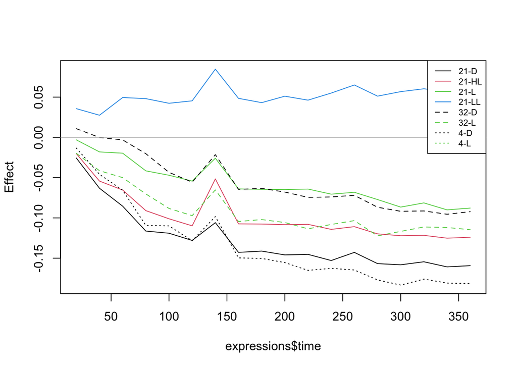

```r
plot(res_expressions, species = FALSE, lty=c(1,1,1,1,2,2,3,3), col=c(1,2,3,4,1,3,1,3), legpos = NA)
legend("topright",legend = levels(expressions$condition),lty=c(1,1,1,1,2,2,3,3), col=c(1,2,3,4,1,3,1,3), cex=0.7)
```